# NLP_Project_Full_Code_1

## **Problem Statement**

### Business Context

The prices of the stocks of companies listed under a global exchange are influenced by a variety of factors, with the company's financial performance, innovations and collaborations, and market sentiment being factors that play a significant role. News and media reports can rapidly affect investor perceptions and, consequently, stock prices in the highly competitive financial industry. With the sheer volume of news and opinions from a wide variety of sources, investors and financial analysts often struggle to stay updated and accurately interpret its impact on the market. As a result, investment firms need sophisticated tools to analyze market sentiment and integrate this information into their investment strategies.

### Problem Definition

With an ever-rising number of news articles and opinions, an investment startup aims to leverage artificial intelligence to address the challenge of interpreting stock-related news and its impact on stock prices. They have collected historical daily news for a specific company listed under NASDAQ, along with data on its daily stock price and trade volumes.

As a member of the Data Science and AI team in the startup, you have been tasked with analyzing the data, developing an AI-driven sentiment analysis system that will automatically process and analyze news articles to gauge market sentiment, and summarizing the news at a weekly level to enhance the accuracy of their stock price predictions and optimize investment strategies. This will empower their financial analysts with actionable insights, leading to more informed investment decisions and improved client outcomes.

### Data Dictionary

- `Date` : The date the news was released
- `News` : The content of news articles that could potentially affect the company's stock price
- `Open` : The stock price (in \$) at the beginning of the day
- `High` : The highest stock price (in \$) reached during the day
- `Low` : The lowest stock price (in \$) reached during the day
- `Close` : The adjusted stock price (in \$) at the end of the day
- `Volume` : The number of shares traded during the day
- `Label` : The sentiment polarity of the news content
  - 1: positive
  - 0: neutral
  - -1: negative

## **Please read the instructions carefully before starting the project.**

**Note**: If the free-tier GPU of Google Colab is not accessible (due to unavailability or exhaustion of daily limit or other reasons), the following steps can be taken:

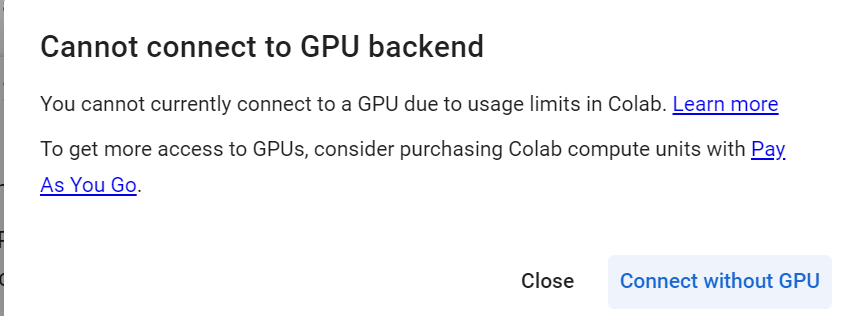

## **Installing and Importing Necessary Libraries**

```python
# installing libraries to use word embeddings
!pip install gensim==4.3.3 pandas==2.2.2 numpy==1.26.4 matplotlib==3.10.0 seaborn==0.13.2 nltk==3.9.1 scikit-learn==1.6.1 -q
```

[output not shown]

```python
# to read and manipulate the data
import pandas as pd
import numpy as np
pd.set_option('max_colwidth', None)    # setting column to the maximum column width as per the data

# to visualise data
import matplotlib.pyplot as plt
import seaborn as sns

# to use regular expressions for manipulating text data
import re

# to load the natural language toolkit
import nltk
nltk.download('stopwords')    # loading the stopwords
nltk.download('wordnet')    # loading the wordnet module that is used in stemming

# to remove common stop words
from nltk.corpus import stopwords

# to perform stemming
from nltk.stem.porter import PorterStemmer

# To encode the target variable
from sklearn.preprocessing import LabelEncoder

# To import Word2Vec
from gensim.models import Word2Vec

# To tune the model
from sklearn.model_selection import GridSearchCV

# Converting the Stanford GloVe model vector format to word2vec
from gensim.scripts.glove2word2vec import glove2word2vec
from gensim.models import KeyedVectors

# To split data into train and test sets
from sklearn.model_selection import train_test_split

# To build a Random Forest model
from sklearn.ensemble import RandomForestClassifier

# To compute metrics to evaluate the model
from sklearn.metrics import confusion_matrix, accuracy_score, f1_score, precision_score, recall_score, classification_report
```

[output not shown]

## **Loading the dataset**

```python
df = pd.read_csv('stock_news.csv')
```

```python
data = df.copy()
```

## **Data Overview**

```python
data.head()
```

|  | Date | News | Open | High | Low | Close | Volume | Label |
| --- | --- | --- | --- | --- | --- | --- | --- | --- |
| 0 | 2019-01-02 | The tech sector experienced a significant decline in the aftermarket following Apple's Q1 revenue warning. Notable suppliers, including Skyworks, Broadcom, Lumentum, Qorvo, and TSMC, saw their stocks … | 41.740002 | 42.244999 | 41.482498 | 40.246914 | 130672400 | -1 |
| 1 | 2019-01-02 | Apple lowered its fiscal Q1 revenue guidance to $84 billion from earlier estimates of $89-$93 billion due to weaker than expected iPhone sales. The announcement caused a significant drop in Apple's st… | 41.740002 | 42.244999 | 41.482498 | 40.246914 | 130672400 | -1 |
| 2 | 2019-01-02 | Apple cut its fiscal first quarter revenue forecast from $89-$93 billion to $84 billion due to weaker demand in China and fewer iPhone upgrades. CEO Tim Cook also mentioned constrained sales of Airpod… | 41.740002 | 42.244999 | 41.482498 | 40.246914 | 130672400 | -1 |
| 3 | 2019-01-02 | This news article reports that yields on long-dated U.S. Treasury securities hit their lowest levels in nearly a year on January 2, 2019, due to concerns about the health of the global economy followi… | 41.740002 | 42.244999 | 41.482498 | 40.246914 | 130672400 | -1 |
| 4 | 2019-01-02 | Apple's revenue warning led to a decline in USD JPY pair and a gain in Japanese yen, as investors sought safety in the highly liquid currency. Apple's underperformance in Q1, with forecasted revenue o… | 41.740002 | 42.244999 | 41.482498 | 40.246914 | 130672400 | -1 |

```python
data.shape
```

```
(349, 8)
```

```python
data.isnull().sum()
```

|  | 0 |
| --- | --- |
| Date | 0 |
| News | 0 |
| Open | 0 |
| High | 0 |
| Low | 0 |
| Close | 0 |
| Volume | 0 |
| Label | 0 |

**dtype:** int64

## **Exploratory Data Analysis**

```python
def labeled_barplot(data, feature, perc=False, n=None):

    total = len(data[feature])  # length of the column
    count = data[feature].nunique()
    if n is None:
        plt.figure(figsize=(count + 1, 5))
    else:
        plt.figure(figsize=(n + 1, 5))

    plt.xticks(rotation=90, fontsize=15)
    ax = sns.countplot(
        data=data,
        x=feature,
        palette="Paired",
        order=data[feature].value_counts().index[:n].sort_values(),
    )

    for p in ax.patches:
        if perc == True:
            label = "{:.1f}%".format(
                100 * p.get_height() / total
            )  # percentage of each class of the category
        else:
            label = p.get_height()  # count of each level of the category

        x = p.get_x() + p.get_width() / 2  # width of the plot
        y = p.get_height()  # height of the plot

        ax.annotate(
            label,
            (x, y),
            ha="center",
            va="center",
            size=12,
            xytext=(0, 5),
            textcoords="offset points",
        )  # annotate the percentage

    plt.show()  # show the plot
```

### Univariate Analysis

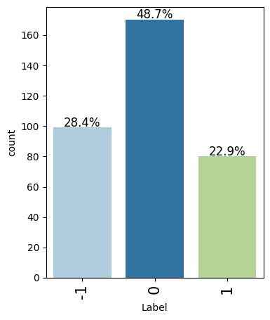

```python
labeled_barplot(data, "Label", perc=True)
```

[figure not shown]

```python
labeled_barplot(data, "Volume", perc=True)
```

[figure not shown]

```python
labeled_barplot(data, "Low", perc=True)
```

[output not shown]

### Bivariate Analysis

- Correlation
- Sentiment Polarity vs Price
- Date vs Price

**Note**: The above points are listed to provide guidance on how to approach bivariate analysis. Analysis has to be done beyond the above listed points to get maximum scores.

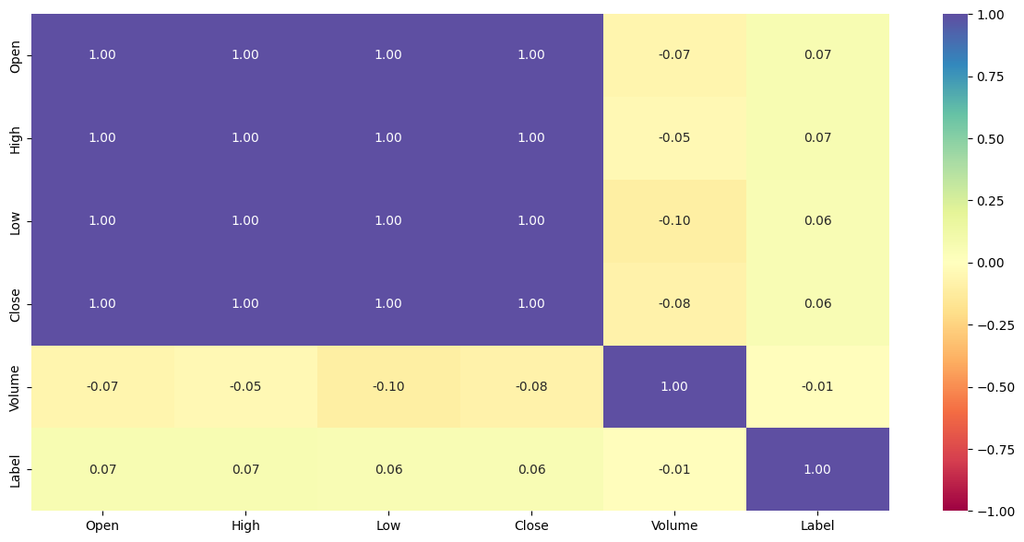

```python
cols_list = data.select_dtypes(include=np.number).columns.tolist()


plt.figure(figsize=(15, 7))
sns.heatmap(
    data[cols_list].corr(), annot=True, vmin=-1, vmax=1, fmt=".2f", cmap="Spectral"
)
plt.show()
```

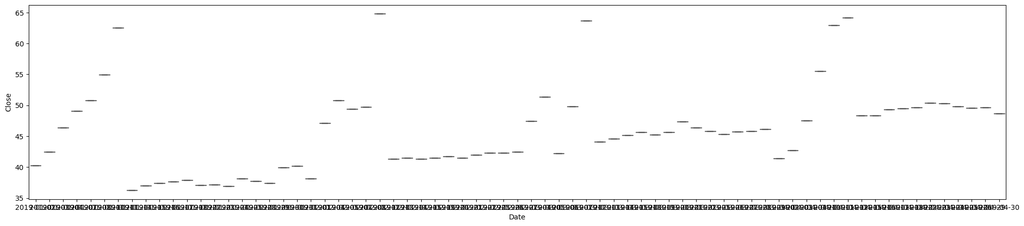

```python
plt.figure(figsize=(25, 5))
sns.boxplot(x="Date", y="Close", data=data)
plt.show()
```

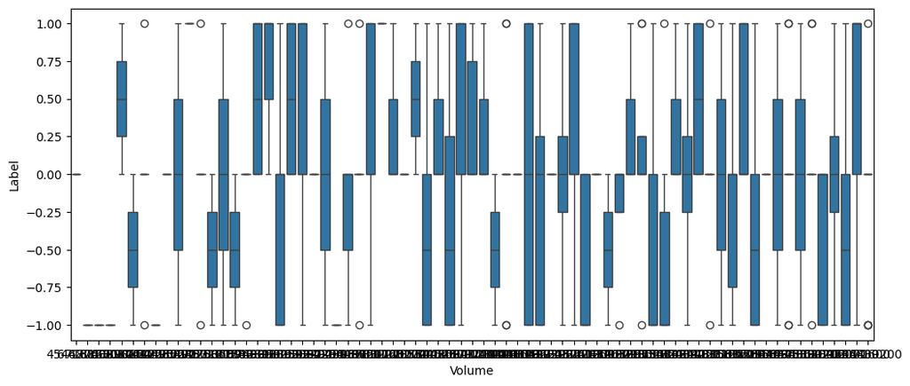

```python
plt.figure(figsize=(12, 5))
sns.boxplot(x="Volume", y="Label", data=data)
plt.show()
```

## **Data Preprocessing**

Preprocessing the textual column

```python
# Loading the Porter Stemmer
ps = PorterStemmer()
```

```python
def preprocess_text(text):
    # Convert to lowercase
    text = text.lower()

    # Remove special characters and numbers
    text = re.sub(r'[^A-Za-z\s]', '', text)

    # Remove extra whitespaces
    text = re.sub(r'\s+', ' ', text).strip()

    # Split text into separate words
    words = text.split()

    # Removing English language stopwords
    text = ' '.join([word for word in words if word not in stopwords.words('english')])

    # Applying the Porter Stemmer on every word of a message and joining the stemmed words back into a single string
    text = ' '.join([ps.stem(word) for word in words])

    return text
```

```python
# preprocessing the textual column
data['Article_text_clean'] = data['News'].apply(preprocess_text)
```

## **Word Embeddings**

### Word2Vec

```python
# Creating a list of all words in our data
words_list = [item.split(" ") for item in data['Article_text_clean'].values]
```

```python
# Creating an instance of Word2Vec
vec_size = 300
model_W2V = Word2Vec(words_list, vector_size = vec_size, min_count = 1, window=5, workers = 6)
```

```python
# Checking the word embedding of a random word
word = "airpod"
model_W2V.wv[word]
```

```
array([-2.50542024e-03,  1.30865844e-02,  8.89178191e-05,  2.24941410e-03,
       -1.48357812e-03, -1.06091807e-02,  7.25914072e-03,  2.95820683e-02,
        1.46786205e-03, -3.92135978e-03, -4.91083716e-04, -1.04773464e-02,
       -6.52297575e-04,  1.65875812e-04, -9.29940119e-03, -7.98614323e-03,
        3.65872378e-03, -2.45499494e-03,  3.41180642e-03, -6.64123055e-03,
       -7.11274752e-03, -7.61423376e-04,  1.29330894e-02,  4.48053796e-03,
        9.19476803e-03, -1.41447701e-03, -1.12850759e-02,  6.63123094e-03,
       -3.15671996e-03, -1.24157919e-02, -2.22046068e-03, -4.66671959e-03,
        8.86181544e-04, -4.22106078e-03, -3.00353672e-03,  1.80234958e-03,
        5.56108169e-03, -1.37413153e-02,  7.68797530e-04,  1.32278504e-03,
       -8.52452498e-03, -4.35598136e-04,  1.93452695e-03, -1.14942659e-02,
        1.60539208e-03,  7.49391923e-03,  4.84481454e-03,  5.48553327e-03,
        1.20274432e-03,  1.24365250e-02,  5.91837196e-03,  4.23042569e-04,
       -3.71746183e-03,  7.01688055e-04,  1.86936173e-03,  1.17130876e-02,
        8.52394756e-03,  7.17221643e-04,  2.62696482e-03, -3.87266569e-04,
       -6.17407402e-03, -1.72609731e-03,  3.74153163e-03, -1.15583872e-03,
        1.82373845e-03,  4.90267295e-03,  2.29309965e-03,  7.58007262e-03,
       -3.03548668e-03, -5.20773232e-03,  3.06528294e-03,  2.67030578e-03,
        1.25567000e-02, -5.54154534e-03,  4.79822978e-03,  5.83470706e-03,
       -8.99553020e-03, -3.58006328e-05, -4.90647741e-03,  8.29181634e-03,
       -4.41131741e-03, -1.00246295e-02,  5.29963581e-04,  2.42416654e-02,
        2.13515872e-04,  2.12334024e-04, -5.98423835e-03,  2.78996537e-03,
        9.12324153e-03,  4.20755614e-03,  1.07975109e-02, -2.93052965e-03,
        7.36098038e-03, -2.51594954e-03,  1.15003334e-02,  1.23011367e-02,
        1.38417818e-02, -8.66820011e-03, -6.68724580e-03,  7.69326463e-03,
       -6.50829636e-03,  2.63374182e-03,  9.73877870e-03,  4.22020815e-03,
        3.73663264e-03, -7.22779846e-03, -7.93740910e-05,  1.25116843e-03,
       -9.61186271e-03,  6.64595887e-03, -1.66850947e-02, -4.86828433e-03,
       -1.85070781e-03,  5.95425162e-03,  3.91768152e-03,  3.05416808e-03,
       -3.23300948e-03, -1.49008562e-03,  1.26251923e-02, -1.53805194e-02,
        2.74477014e-03,  8.96229036e-03,  7.07429415e-03,  4.36101295e-03,
       -6.36413274e-03,  5.42564457e-03,  3.84777971e-03, -9.48343333e-03,
        1.48779433e-03,  8.22110660e-03,  3.92064219e-03,  1.39691811e-02,
        7.43670203e-03, -1.10293245e-02,  5.18746115e-03,  1.04368152e-02,
       -2.45151180e-03, -2.47795111e-03, -6.99932501e-03, -1.29934205e-02,
        1.48044992e-03, -1.48337614e-02, -1.84925681e-03,  7.19793234e-03,
        6.22808607e-03, -3.91870132e-03, -1.23856971e-02, -4.44850838e-03,
        1.03712818e-02, -4.22967877e-03,  8.01973685e-04, -1.68596208e-02,
       -4.08217218e-03, -8.84608272e-03,  4.12245793e-03,  3.84071120e-03,
       -7.49837048e-03, -1.28152799e-02, -3.55628028e-04,  1.39835114e-02,
```

[output cut: 21 more lines]

```
        6.38016406e-03, -7.98486918e-03, -3.60231032e-03,  3.88883636e-03,
        1.64489273e-03,  9.13967192e-03,  1.01291668e-02,  1.24732222e-04,
        8.05005152e-03, -1.33278361e-03, -1.30336164e-02, -1.32086664e-03,
        1.81287639e-02,  2.23914371e-03, -1.98516510e-02, -7.84629676e-03,
        1.60300557e-03,  5.52739715e-03,  2.43598968e-03, -1.83448661e-02,
       -8.47269222e-03,  7.82880932e-04, -1.05177856e-03,  5.52104600e-03,
       -8.37409683e-03,  8.15694220e-04, -9.20927711e-03, -2.13618670e-03,
        5.46248222e-04, -4.59453324e-03,  1.30443219e-02,  3.37606971e-03,
        1.01588629e-02, -1.76460657e-04, -1.37481224e-02,  1.77629374e-03,
        6.85122842e-03, -2.70899641e-03, -2.22941185e-03,  6.93554932e-04,
        2.16107830e-04,  5.18999156e-03, -1.16819991e-02,  6.58521894e-03,
        6.93847716e-04,  1.01235835e-02,  2.75027915e-03,  1.21717937e-02,
        1.19960206e-02,  5.42557240e-03,  1.49153899e-02,  1.15986457e-02,
        3.81709356e-03, -6.15402730e-03,  8.24563298e-03, -3.62015399e-03],
      dtype=float32)
```

```python
# Retrieving the words present in the Word2Vec model's vocabulary
words = list(model_W2V.wv.key_to_index.keys())

# Retrieving word vectors for all the words present in the model's vocabulary
wvs = model_W2V.wv[words].tolist()

# Creating a dictionary of words and their corresponding vectors
word_vector_dict = dict(zip(words, wvs))
```

```python
def average_vectorizer_Word2Vec(doc):
    # Initializing a feature vector for the sentence
    feature_vector = np.zeros((vec_size,), dtype="float64")

    # Creating a list of words in the sentence that are present in the model vocabulary
    words_in_vocab = [word for word in doc.split() if word in words]

    # adding the vector representations of the words
    for word in words_in_vocab:
        feature_vector += np.array(word_vector_dict[word])

    # Dividing by the number of words to get the average vector
    if len(words_in_vocab) != 0:
        feature_vector /= len(words_in_vocab)

    return feature_vector
```

```python
# creating a dataframe of the vectorized documents
df_Word2Vec = pd.DataFrame(data['Article_text_clean'].apply(average_vectorizer_Word2Vec).tolist(), columns=['Feature '+str(i) for i in range(vec_size)])
df_Word2Vec
```

|  | Feature 0 | Feature 1 | Feature 2 | Feature 3 | Feature 4 | Feature 5 | Feature 6 | Feature 7 | Feature 8 | Feature 9 | ... | Feature 290 | Feature 291 | Feature 292 | Feature 293 | Feature 294 | Feature 295 | Feature 296 | Feature 297 | Feature 298 | Feature 299 |
| --- | --- | --- | --- | --- | --- | --- | --- | --- | --- | --- | --- | --- | --- | --- | --- | --- | --- | --- | --- | --- | --- |
| 0 | -0.061178 | 0.155731 | 0.017144 | 0.041421 | -0.008514 | -0.153262 | 0.082905 | 0.377494 | 0.043743 | -0.085080 | ... | 0.061717 | 0.201088 | 0.133118 | 0.054724 | 0.220558 | 0.197293 | 0.021647 | -0.111557 | 0.129764 | -0.069972 |
| 1 | -0.061708 | 0.158724 | 0.017368 | 0.041927 | -0.008611 | -0.155772 | 0.084297 | 0.384177 | 0.044437 | -0.086691 | ... | 0.062635 | 0.204539 | 0.135177 | 0.055421 | 0.223964 | 0.200913 | 0.022416 | -0.113504 | 0.132276 | -0.071602 |
| 2 | -0.055265 | 0.140914 | 0.015462 | 0.036240 | -0.007461 | -0.138489 | 0.074881 | 0.341450 | 0.039568 | -0.077106 | ... | 0.055659 | 0.181727 | 0.120315 | 0.049573 | 0.199279 | 0.178624 | 0.019412 | -0.100529 | 0.117294 | -0.063302 |
| 3 | -0.060102 | 0.154128 | 0.016821 | 0.040667 | -0.008001 | -0.151108 | 0.080848 | 0.372313 | 0.043513 | -0.083989 | ... | 0.060316 | 0.198623 | 0.131305 | 0.054326 | 0.216984 | 0.195457 | 0.020624 | -0.110054 | 0.127512 | -0.068898 |
| 4 | -0.060457 | 0.154415 | 0.016843 | 0.040971 | -0.008251 | -0.151787 | 0.081648 | 0.374231 | 0.043471 | -0.084185 | ... | 0.060872 | 0.199469 | 0.132143 | 0.054866 | 0.218415 | 0.195722 | 0.021476 | -0.110399 | 0.128481 | -0.069299 |
| ... | ... | ... | ... | ... | ... | ... | ... | ... | ... | ... | ... | ... | ... | ... | ... | ... | ... | ... | ... | ... | ... |
| 344 | -0.041849 | 0.107453 | 0.012343 | 0.028631 | -0.005447 | -0.105662 | 0.057059 | 0.260411 | 0.030941 | -0.058524 | ... | 0.042254 | 0.138990 | 0.091737 | 0.037838 | 0.152215 | 0.137262 | 0.014581 | -0.076417 | 0.089821 | -0.048197 |
| 345 | -0.041708 | 0.106707 | 0.011831 | 0.028365 | -0.004923 | -0.104761 | 0.056604 | 0.257387 | 0.030070 | -0.057860 | ... | 0.041609 | 0.136959 | 0.090633 | 0.037868 | 0.149927 | 0.134499 | 0.014848 | -0.076009 | 0.088934 | -0.046963 |
| 346 | -0.048338 | 0.123122 | 0.012850 | 0.032230 | -0.005969 | -0.121213 | 0.065343 | 0.297878 | 0.034835 | -0.066957 | ... | 0.047849 | 0.159199 | 0.104781 | 0.043410 | 0.174078 | 0.155946 | 0.017154 | -0.088088 | 0.101784 | -0.054985 |
| 347 | -0.055868 | 0.142868 | 0.015501 | 0.037661 | -0.007751 | -0.140049 | 0.075552 | 0.345289 | 0.040293 | -0.077556 | ... | 0.056458 | 0.183837 | 0.121467 | 0.050366 | 0.201804 | 0.180525 | 0.019517 | -0.101573 | 0.119004 | -0.063814 |
| 348 | -0.060548 | 0.155044 | 0.017602 | 0.040735 | -0.008166 | -0.152091 | 0.081815 | 0.375261 | 0.044465 | -0.084562 | ... | 0.061101 | 0.199761 | 0.132195 | 0.054343 | 0.218875 | 0.196374 | 0.021215 | -0.110382 | 0.128585 | -0.069311 |

349 rows × 300 columns

### GloVe

```python
from gensim.models import KeyedVectors
# load the Stanford GloVe model
filename = '/content/glove.6B.100d.txt.word2vec'
glove_model = KeyedVectors.load_word2vec_format(filename, binary=False)
```

```python
# Retrieving the words present in the GloVe model's vocabulary
glove_words = glove_model.index_to_key

# Creating a dictionary of words and their corresponding vectors
glove_word_vector_dict = dict(zip(glove_model.index_to_key,list(glove_model.vectors)))
```

```python
vec_size=100
```

```python
def average_vectorizer_GloVe(doc):
    # Initializing a feature vector for the sentence
    feature_vector = np.zeros((vec_size,), dtype="float64")

    # Creating a list of words in the sentence that are present in the model vocabulary
    words_in_vocab = [word for word in doc.split() if word in glove_words]

    # adding the vector representations of the words
    for word in words_in_vocab:
        feature_vector += np.array(glove_word_vector_dict[word])

    # Dividing by the number of words to get the average vector
    if len(words_in_vocab) != 0:
        feature_vector /= len(words_in_vocab)

    return feature_vector
```

```python
# creating a dataframe of the vectorized documents
df_Glove = pd.DataFrame(data['Article_text_clean'].apply(average_vectorizer_GloVe).tolist(), columns=['Feature '+str(i) for i in range(vec_size)])
df_Glove
```

|  | Feature 0 | Feature 1 | Feature 2 | Feature 3 | Feature 4 | Feature 5 | Feature 6 | Feature 7 | Feature 8 | Feature 9 | ... | Feature 90 | Feature 91 | Feature 92 | Feature 93 | Feature 94 | Feature 95 | Feature 96 | Feature 97 | Feature 98 | Feature 99 |
| --- | --- | --- | --- | --- | --- | --- | --- | --- | --- | --- | --- | --- | --- | --- | --- | --- | --- | --- | --- | --- | --- |
| 0 | -0.025091 | 0.042967 | 0.116176 | -0.099245 | -0.099562 | -0.266941 | -0.129265 | 0.080286 | -0.090646 | 0.008517 | ... | -0.017063 | 0.156885 | -0.173618 | 0.017792 | -0.351731 | 0.080720 | -0.009300 | -0.071766 | 0.400022 | 0.046329 |
| 1 | 0.075789 | 0.279267 | 0.286092 | -0.077898 | -0.022339 | -0.379945 | -0.178142 | -0.061498 | -0.161026 | 0.088777 | ... | -0.016551 | 0.146223 | -0.238209 | -0.091082 | -0.463150 | 0.093832 | 0.016530 | -0.174671 | 0.531049 | -0.026343 |
| 2 | 0.014897 | 0.207172 | 0.331676 | -0.114473 | 0.116600 | -0.374662 | -0.168155 | -0.010315 | -0.086171 | 0.033631 | ... | 0.120662 | 0.082600 | -0.143998 | -0.157486 | -0.532710 | 0.129624 | -0.030218 | -0.157017 | 0.557803 | -0.121953 |
| 3 | -0.090954 | 0.123357 | 0.444133 | -0.051370 | 0.011666 | -0.228597 | -0.246173 | 0.033390 | -0.150130 | 0.002191 | ... | 0.082228 | 0.127173 | -0.272930 | 0.134984 | -0.438773 | 0.074060 | -0.046727 | -0.261468 | 0.554238 | 0.067364 |
| 4 | -0.016286 | 0.095670 | 0.158662 | 0.009404 | 0.022072 | -0.162877 | -0.133161 | -0.037780 | -0.213474 | 0.109459 | ... | 0.076108 | 0.076419 | -0.141350 | -0.127092 | -0.298950 | 0.181038 | 0.048829 | -0.186550 | 0.361910 | -0.034064 |
| ... | ... | ... | ... | ... | ... | ... | ... | ... | ... | ... | ... | ... | ... | ... | ... | ... | ... | ... | ... | ... | ... |
| 344 | -0.089744 | 0.078603 | 0.355204 | -0.269606 | 0.093859 | 0.229220 | -0.084779 | 0.248824 | -0.119752 | 0.015531 | ... | 0.113815 | -0.164158 | 0.054945 | 0.112785 | -0.391273 | 0.064565 | -0.150172 | -0.331076 | 0.552668 | 0.277021 |
| 345 | 0.153751 | 0.155163 | 0.296305 | 0.042006 | 0.105729 | -0.252609 | -0.260229 | -0.007662 | -0.240935 | -0.035625 | ... | 0.056417 | 0.102090 | -0.138025 | 0.059017 | -0.511696 | 0.348926 | 0.062021 | -0.030892 | 0.483785 | 0.106074 |
| 346 | 0.033072 | 0.072522 | 0.241457 | -0.146820 | -0.050864 | -0.095216 | -0.124294 | 0.112551 | -0.242520 | -0.060998 | ... | -0.011031 | 0.144369 | -0.168728 | 0.120561 | -0.412585 | -0.009892 | -0.123141 | -0.258367 | 0.350678 | 0.055361 |
| 347 | -0.113620 | 0.056063 | 0.216818 | -0.095542 | 0.004862 | -0.195284 | -0.223138 | 0.078362 | -0.195751 | -0.034510 | ... | 0.025093 | 0.007117 | -0.140764 | -0.045426 | -0.433007 | 0.026847 | 0.035699 | -0.281933 | 0.497955 | 0.019963 |
| 348 | 0.008440 | 0.193835 | 0.308262 | -0.132214 | 0.036220 | -0.192029 | -0.036471 | 0.145628 | -0.261896 | 0.041172 | ... | 0.035777 | 0.057962 | -0.283714 | 0.201147 | -0.489115 | 0.031632 | -0.063183 | -0.214501 | 0.710835 | -0.138350 |

349 rows × 100 columns

### Sentence Transformers

```python
from sentence_transformers import SentenceTransformer
from transformers import T5Tokenizer, T5ForConditionalGeneration, pipeline
```

```
WARNING:torchao.kernel.intmm:Warning: Detected no triton, on systems without Triton certain kernels will not work
```

```python
#Defining the model
model = SentenceTransformer('sentence-transformers/all-MiniLM-L6-v2')
```

```python
# encoding the dataset
embedding_matrix = model.encode(data['News'], show_progress_bar=True)
```

```python
# printing the shape of the embedding matrix
embedding_matrix.shape
```

```
(349, 384)
```

```python
# printing the embedding vector of the first review in the dataset
embedding_matrix[0]
```

```
array([-2.02313159e-03, -3.67734767e-02,  7.73542821e-02,  4.67134863e-02,
        3.25521603e-02,  2.10235314e-03,  4.32834662e-02,  3.95345129e-02,
        5.82279675e-02,  8.87510274e-03,  7.09636360e-02,  4.99076843e-02,
        6.46608472e-02, -4.97969892e-03, -1.30518824e-02, -2.98355483e-02,
       -8.91323388e-03, -7.82000571e-02, -2.17109602e-02, -5.24823181e-02,
       -5.14276326e-02, -3.30719724e-02, -3.32051739e-02,  4.18126024e-02,
        7.99547434e-02,  1.54092591e-02, -2.15781815e-02,  5.19439541e-02,
       -4.65799198e-02, -3.71372215e-02, -1.04225568e-01,  9.86079201e-02,
        5.21786660e-02,  3.46579105e-02,  1.48810120e-02, -4.47349763e-03,
        5.70117570e-02, -2.41722949e-02,  2.14048848e-02, -6.52144775e-02,
       -3.30644958e-02,  1.61960311e-02, -6.63141757e-02,  4.39942963e-02,
        3.82153057e-02, -4.86519225e-02,  1.62651595e-02, -4.02664989e-02,
       -3.34572373e-03,  3.20955552e-02, -3.91194923e-03, -1.26830228e-02,
        4.49699089e-02,  3.39314155e-02, -5.17101139e-02,  5.32579012e-02,
       -4.53628674e-02, -2.19655335e-02,  7.14351535e-02,  3.10436301e-02,
        4.33289707e-02, -9.26511139e-02,  1.73019227e-02, -8.11778288e-03,
        6.26880452e-02, -1.42352665e-02, -4.14227284e-02,  5.68226799e-02,
       -8.62419680e-02,  6.02036230e-02,  4.75493260e-02, -7.17870295e-02,
        1.17750298e-02,  4.39625680e-02, -3.44557762e-02,  3.67183983e-02,
        5.21757044e-02, -2.14000586e-02, -5.96953277e-03,  8.72076955e-03,
        3.53134982e-02, -3.95235755e-02, -9.36869159e-02,  1.56855360e-02,
       -3.84228714e-02,  2.47945245e-02,  3.62802744e-02, -1.32978568e-02,
       -4.67082411e-02, -5.69417290e-02,  6.84318021e-02, -2.25545582e-03,
        1.43187167e-02, -1.19596571e-02,  5.61927333e-02, -5.40326014e-02,
        1.84007995e-02, -9.87436175e-02,  1.36832688e-02,  1.76981930e-02,
        4.83816713e-02,  3.39467973e-02,  5.20425737e-02, -3.35445814e-02,
       -4.39126305e-02, -9.73524824e-02,  4.13891077e-02,  2.77669472e-03,
        3.94194871e-02,  1.73664503e-02, -2.37191115e-02,  1.02214953e-02,
       -5.20212315e-02, -4.82434928e-02, -6.77878335e-02,  7.58207887e-02,
       -1.03107970e-02,  6.10160567e-02, -4.92668450e-02, -1.84614025e-02,
       -5.64167760e-02,  6.09037206e-02, -4.93273232e-03,  1.02207549e-02,
        3.61768007e-02,  1.62944235e-02, -1.01151660e-01, -9.37191799e-34,
        1.30963763e-02,  2.90462505e-02, -5.68401404e-02, -1.07232891e-02,
        3.43216136e-02, -5.42572476e-02,  6.12290204e-02,  6.73200516e-03,
       -6.39356151e-02, -3.71847749e-02, -4.51455973e-02,  5.50827943e-02,
       -5.48340566e-02, -9.50715691e-02,  7.80200139e-02, -1.12085886e-01,
       -5.90518229e-02, -8.70309863e-03,  6.69128671e-02, -2.09152903e-02,
       -4.48345318e-02, -6.54890686e-02, -5.31035624e-02,  6.96216524e-02,
        8.78790021e-03,  7.72863161e-04,  1.89885020e-03,  3.55077311e-02,
        1.91084035e-02,  2.86549982e-02, -5.54806776e-02,  6.67084903e-02,
```

[output cut: 42 more lines]

```
        1.08690016e-01,  3.81879397e-02, -7.81213567e-02, -1.09489299e-02,
       -1.17989436e-01,  7.97276199e-02,  2.46654786e-02,  9.32570198e-04,
       -7.25727007e-02,  8.93293787e-03,  4.05105166e-02, -1.03700541e-01,
       -6.20271405e-03,  3.49569246e-02,  7.82293528e-02, -2.42466480e-02,
       -3.33974175e-02,  3.95032652e-02,  1.34982972e-03, -7.48428553e-02,
        5.03438413e-02,  5.74473524e-03, -2.39702258e-02,  1.32115034e-03,
        6.57341555e-02, -5.62655777e-02, -6.76572174e-02, -4.22493443e-02,
       -2.64710821e-02,  2.83032618e-02,  4.93412055e-02,  3.14058885e-02,
       -3.22603956e-02, -1.48834186e-02, -7.07752854e-02, -9.63545498e-03,
       -3.38621214e-02, -1.05421599e-02, -5.47045544e-02,  2.66298074e-02,
        5.15929870e-02, -1.93036627e-02,  1.74268279e-02, -2.24287789e-02,
        5.11573628e-04,  2.79130489e-02, -6.66390657e-02, -5.92727624e-02,
        3.25671514e-03, -5.93583798e-04, -5.50960638e-02, -2.71336492e-02,
       -3.57511407e-03, -1.31502077e-01,  7.41634741e-02,  5.75100929e-02],
      dtype=float32)
```

## **Sentiment Analysis**

### Model Building

```python
# creating a function to plot the confusion matrix
def plot_confusion_matrix(actual, predicted):
    cm = confusion_matrix(actual, predicted)

    plt.figure(figsize = (5, 4))
    label_list = encoder.classes_.tolist()
    sns.heatmap(cm, annot = True,  fmt = '.0f',cmap='Blues', xticklabels = label_list, yticklabels = label_list)
    plt.ylabel('Actual')
    plt.xlabel('Predicted')
    plt.title('Confusion Matrix')
    plt.show()
```

```python
# defining a function to compute different metrics to check performance of a classification model built using sklearn
def model_performance_classification_sklearn(model, predictors, target):
    """
    Function to compute different metrics to check classification model performance

    model: classifier
    predictors: independent variables
    target: dependent variable
    """

    # predicting using the independent variables
    pred = model.predict(predictors)

    acc = accuracy_score(target, pred)  # to compute Accuracy
    recall = recall_score(target, pred, average='weighted')  # to compute Recall
    precision = precision_score(target, pred, average='weighted')  # to compute Precision
    f1 = f1_score(target, pred, average='weighted')  # to compute F1-score

    # creating a dataframe of metrics
    df_perf = pd.DataFrame(
        {
            "Accuracy": acc,
            "Recall": recall,
            "Precision": precision,
            "F1": f1,
        },
        index=[0],
    )

    return df_perf
```

### Random Forest with Word2Vec

```python
# Storing independent variable
X = df_Word2Vec.copy()

# Storing target variable
y = data['Label']
```

```python
# Split data into training and testing set.
X_train, X_test, y_train, y_test = train_test_split(X ,y, test_size = 0.25, random_state = 42)
```

```python
# Label Encoding
encoder = LabelEncoder()

# fitting the encoder to the training labels
y_train_enc = encoder.fit_transform(y_train)

# applying the encoder mapping from training labels to test labels
y_test_enc = encoder.transform(y_test)
```

```python
# Building the model
rf_word2vec_base = RandomForestClassifier(class_weight= "balanced",random_state = 42)

# Fitting on train data
rf_word2vec_base.fit(X_train, y_train_enc)
```

```
RandomForestClassifier(class_weight='balanced', random_state=42)
```

```python
# Predicting on train data
y_pred_train_base = rf_word2vec_base.predict(X_train)

# Predicting on test data
y_pred_test_base = rf_word2vec_base.predict(X_test)
```

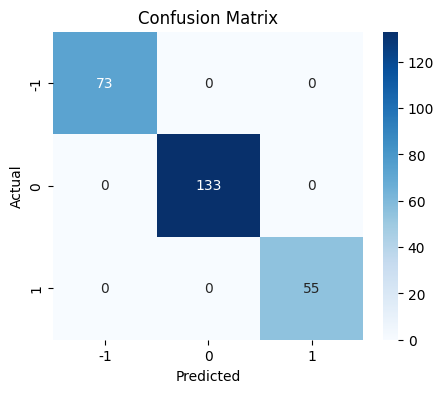

```python
plot_confusion_matrix(y_train_enc, y_pred_train_base)
```

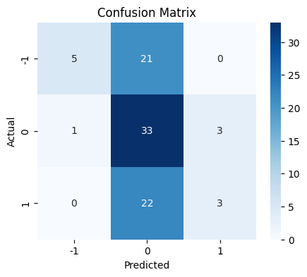

```python
plot_confusion_matrix(y_test_enc, y_pred_test_base)
```

```python
#Calculating different metrics on training data
word2vec_base_train=model_performance_classification_sklearn(rf_word2vec_base, X_train,y_train_enc)
print("Training performance:\n", word2vec_base_train)
```

```
Training performance:
    Accuracy  Recall  Precision   F1
0       1.0     1.0        1.0  1.0
```

```python
#Calculating different metrics on testing data
word2vec_base_test=model_performance_classification_sklearn(rf_word2vec_base, X_test,y_test_enc)
print("Testing performance:\n", word2vec_base_test)
```

```
Testing performance:
    Accuracy    Recall  Precision       F1
0  0.465909  0.465909   0.570823  0.39289
```

### RF model with hyperparameter

```python
# Choose the type of classifier.
word2vec_rf_tuned = RandomForestClassifier(class_weight= "balanced",random_state=42,bootstrap=True)

parameters = {
    'max_depth': list(np.arange(5,10,25)),
    'n_estimators': np.arange(50,100,75),
    'max_features': [0.3,0.5]
}

# Run the grid search
grid_obj = GridSearchCV(word2vec_rf_tuned, parameters, scoring='recall',cv=5,n_jobs=-1)
grid_obj = grid_obj.fit(X_train, y_train_enc)

# Set the clf to the best combination of parameters
word2vec_rf_tuned = grid_obj.best_estimator_

# Fit the best algorithm to the data.
word2vec_rf_tuned.fit(X_train, y_train_enc)
```

```
RandomForestClassifier(class_weight='balanced', max_depth=5, max_features=0.3,
                       n_estimators=50, random_state=42)
```

```python
# Predicting on train data
y_pred_train_tuned = word2vec_rf_tuned.predict(X_train)

# Predicting on test data
y_pred_test_tuned = word2vec_rf_tuned.predict(X_test)
```

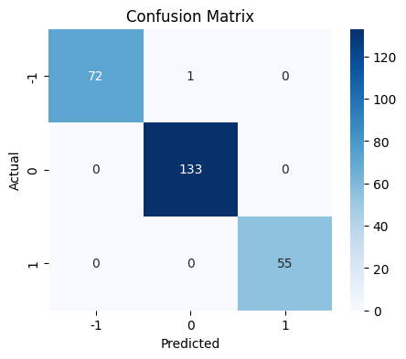

```python
plot_confusion_matrix(y_train_enc, y_pred_train_tuned)
```

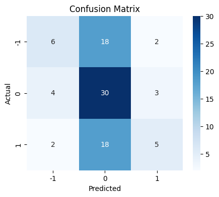

```python
plot_confusion_matrix(y_test_enc, y_pred_test_tuned)
```

```python
#Calculating different metrics on training data
word2vec_tuned_train=model_performance_classification_sklearn(word2vec_rf_tuned, X_train,y_train_enc)
print("Training performance:\n", word2vec_tuned_train)
```

```
Training performance:
    Accuracy    Recall  Precision        F1
0  0.996169  0.996169   0.996197  0.996163
```

```python
#Calculating different metrics on testing data
word2vec_tuned_test=model_performance_classification_sklearn(word2vec_rf_tuned, X_test,y_test_enc)
print("Testing performance:\n", word2vec_tuned_test)
```

```
Testing performance:
    Accuracy    Recall  Precision        F1
0  0.465909  0.465909   0.480888  0.419395
```

### Random Forest with GloVe

```python
# Storing independent variable
X = df_Glove.copy()

# Storing target variable
y = data['Label']
```

```python
# Split data into training and testing set.
X_train_glove, X_test_glove, y_train_glove, y_test_glove = train_test_split(X ,y, test_size = 0.25, random_state = 42)
```

```python
# Label Encoding
encoder = LabelEncoder()

# fitting the encoder to the training labels
y_train_enc_glove = encoder.fit_transform(y_train_glove)

# applying the encoder mapping from training labels to test labels
y_test_enc_glove = encoder.transform(y_test_glove)
```

```python
# Building the model
rf_glovec_base = RandomForestClassifier(class_weight= "balanced",random_state = 42)

# Fitting on train data
rf_glovec_base.fit(X_train_glove, y_train_enc_glove)
```

```
RandomForestClassifier(class_weight='balanced', random_state=42)
```

```python
# Predicting on train data
y_pred_train_base_gl = rf_glovec_base.predict(X_train_glove)

# Predicting on test data
y_pred_test_base_gl = rf_glovec_base.predict(X_test_glove)
```

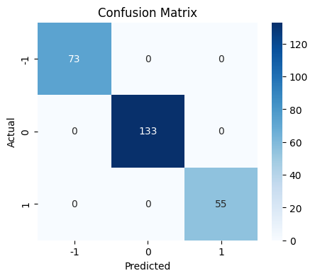

```python
plot_confusion_matrix(y_train_enc_glove, y_pred_train_base_gl)
```

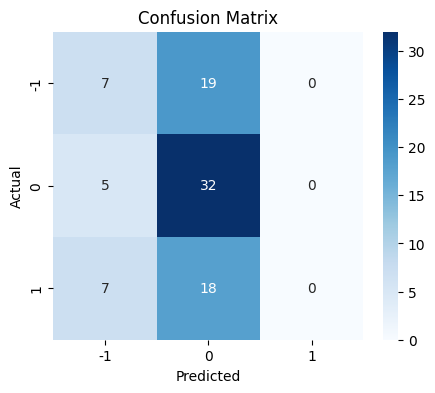

```python
plot_confusion_matrix(y_test_enc_glove, y_pred_test_base_gl)
```

```python
#Calculating different metrics on training data
glove_base_train=model_performance_classification_sklearn(rf_glovec_base, X_train_glove,y_train_enc_glove)
print("Training performance:\n", glove_base_train)
```

```
Training performance:
    Accuracy  Recall  Precision   F1
0       1.0     1.0        1.0  1.0
```

```python
#Calculating different metrics on testing data
glove_base_test=model_performance_classification_sklearn(rf_glovec_base, X_test_glove,y_test_enc_glove)
print("Testing performance:\n", glove_base_test)
```

```
Testing performance:
    Accuracy    Recall  Precision        F1
0  0.443182  0.443182   0.303845  0.345779
```

### RF model with Hyperparameter

```python
# Choose the type of classifier.
glove_rf_tuned = RandomForestClassifier(class_weight= "balanced",random_state=1,bootstrap=True)

parameters = {
    'max_depth': list(np.arange(5,10,2)),
    'n_estimators': np.arange(50,110,25),
    'max_features': [0.3,0.4]
}

# Run the grid search
grid_obj = GridSearchCV(glove_rf_tuned, parameters, scoring='recall',cv=5,n_jobs=-1)
grid_obj = grid_obj.fit(X_train_glove, y_train_enc_glove)

# Set the clf to the best combination of parameters
glove_rf_tuned = grid_obj.best_estimator_

# Fit the best algorithm to the data.
glove_rf_tuned.fit(X_train_glove, y_train_enc_glove)
```

```
RandomForestClassifier(class_weight='balanced', max_depth=5, max_features=0.3,
                       n_estimators=50, random_state=1)
```

```python
# Predicting on train data
y_pred_train_tuned_gl = glove_rf_tuned.predict(X_train_glove)

# Predicting on test data
y_pred_test_tuned_gl = glove_rf_tuned.predict(X_test_glove)
```

```python
#Calculating different metrics on training data
glove_tuned_train=model_performance_classification_sklearn(glove_rf_tuned, X_train_glove,y_train_enc_glove)
print("Training performance:\n", glove_tuned_train)
```

```
Training performance:
    Accuracy    Recall  Precision       F1
0  0.992337  0.992337   0.992542  0.99236
```

```python
#Calculating different metrics on testing data
glove_tuned_test=model_performance_classification_sklearn(glove_rf_tuned, X_test_glove,y_test_enc_glove)
print("Testing performance:\n", glove_tuned_test)
```

```
Testing performance:
    Accuracy    Recall  Precision        F1
0  0.443182  0.443182    0.40428  0.375976
```

### Random Forest with transformer

```python
X = embedding_matrix
y = data["Label"]
X_train, X_test, y_train, y_test = train_test_split(X, y, test_size=0.25, random_state=42)
```

```python
# Building the model
rf_transformer = RandomForestClassifier(n_estimators = 100, max_depth = 5, random_state = 42)

# Fitting on train data
rf_transformer.fit(X_train, y_train)
```

```
RandomForestClassifier(max_depth=5, random_state=42)
```

```python
# Predicting on train data
y_pred_train = rf_transformer.predict(X_train)

# Predicting on test data
y_pred_test = rf_transformer.predict(X_test)
```

```python
#Calculating different metrics on training data
rf_transformer_train=model_performance_classification_sklearn(rf_transformer, X_train,y_train)
print("Training performance:\n", rf_transformer_train)
```

```
Training performance:
    Accuracy    Recall  Precision        F1
0  0.977011  0.977011   0.978004  0.976908
```

```python
#Calculating different metrics on testing data
rf_transformer_test=model_performance_classification_sklearn(rf_transformer, X_test,y_test)
print("Training performance:\n", rf_transformer_test)
```

```
Training performance:
    Accuracy    Recall  Precision        F1
0  0.477273  0.477273   0.623777  0.388215
```

### Model Comparison and Final Model Selection

```python
# training performance comparison

models_train_comp_df = pd.concat(
    [word2vec_base_train.T,word2vec_tuned_train.T,glove_base_train.T,glove_tuned_train.T,rf_transformer_train.T],
    axis=1,
)
models_train_comp_df.columns = [
    "Word2vec - Base RF Model",
    "Word2vec - RF with Grid Search",
    "GloVe - Base RF Model",
    "GloVe - RF with Grid Search",
    "Transformer with hyprpara"]
print("Training performance comparison:")

models_train_comp_df
```

```
Training performance comparison:
```

[output not shown]

```python
# training performance comparison

models_test_comp_df = pd.concat(
    [word2vec_base_test.T,word2vec_tuned_test.T,glove_base_test.T,glove_tuned_test.T,rf_transformer_test.T],
    axis=1,
)
models_test_comp_df.columns = [
    "Word2vec - Base RF Model",
    "Word2vec - RF with Grid Search",
    "GloVe - Base RF Model",
    "GloVe - RF with Grid Search",
    "Transformer with hyprpara"]
print("Testing performance comparison:")

models_test_comp_df
```

```
Testing performance comparison:
```

|  | Word2vec - Base RF Model | Word2vec - RF with Grid Search | GloVe - Base RF Model | GloVe - RF with Grid Search | Transformer with hyprpara |
| --- | --- | --- | --- | --- | --- |
| Accuracy | 0.465909 | 0.465909 | 0.443182 | 0.443182 | 0.477273 |
| Recall | 0.465909 | 0.465909 | 0.443182 | 0.443182 | 0.477273 |
| Precision | 0.570823 | 0.480888 | 0.303845 | 0.404280 | 0.623777 |
| F1 | 0.392890 | 0.419395 | 0.345779 | 0.375976 | 0.388215 |

## **Weekly News Summarization**

**Important Note**: It is recommended to run this section of the project independently from the previous sections in order to avoid runtime crashes due to RAM overload.

#### Installing and Importing the necessary libraries

```python
# Installation for GPU llama-cpp-python
# uncomment and run the following code in case GPU is being used
#!CMAKE_ARGS="-DLLAMA_CUBLAS=on" FORCE_CMAKE=1 pip install llama-cpp-python -q

# Installation for CPU llama-cpp-python
# uncomment and run the following code in case GPU is not being used
!CMAKE_ARGS="-DLLAMA_CUBLAS=off" FORCE_CMAKE=1 pip install llama-cpp-python -q
```

```
     ━━━━━━━━━━━━━━━━━━━━━━━━━━━━━━━━━━━━━━━━ 50.7/50.7 MB 19.3 MB/s eta 0:00:00
  Installing build dependencies ... done
  Getting requirements to build wheel ... done
  Installing backend dependencies ... done
  Preparing metadata (pyproject.toml) ... done
   ━━━━━━━━━━━━━━━━━━━━━━━━━━━━━━━━━━━━━━━━ 45.5/45.5 kB 3.1 MB/s eta 0:00:00
```

```python
# Function to download the model from the Hugging Face model hub
from huggingface_hub import hf_hub_download

# Importing the Llama class from the llama_cpp module
from llama_cpp import Llama

# Importing the library for data manipulation
import pandas as pd

from tqdm import tqdm # For progress bar related functionalities
tqdm.pandas()
```

#### Loading the data

```python
data = pd.read_csv("stock_news.csv")
```

#### Loading the model

```python
model_name_or_path = "TheBloke/Llama-2-13B-chat-GGUF"
model_basename = "llama-2-13b-chat.Q5_K_M.gguf" # the model is in gguf format
```

```python
# Using hf_hub_download to download a model from the Hugging Face model hub
# The repo_id parameter specifies the model name or path in the Hugging Face repository
# The filename parameter specifies the name of the file to download
model_path = hf_hub_download(
    repo_id=model_name_or_path,
    filename=model_basename
)
```

```python
lcpp_llm = Llama(
    model_path=model_path,
    n_threads=2,  # CPU cores
    n_batch=128,  # Should be between 1 and n_ctx, consider the amount of VRAM in your GPU.
    #n_gpu_layers=25,  # uncomment and change this value based on GPU VRAM pool.
    n_ctx=1024,  # Context window
)
```

[output not shown]

[output cut: 139 more lines]

[output not shown]

#### Aggregating the data weekly

```python
data["Date"] = pd.to_datetime(data['Date'])  # Convert the 'Date' column to datetime format.
```

```python
# Group the data by week using the 'Date' column.
weekly_grouped = data.groupby(pd.Grouper(key='Date', freq='W'))
```

```python
weekly_grouped = weekly_grouped.agg(
    {
        'News': lambda x: ' || '.join(x)  # Join the news values with ' || ' separator.
    }
).reset_index()

print(weekly_grouped.shape)
```

```
(18, 2)
```

```python
weekly_grouped
```

|  | Date | News |
| --- | --- | --- |
| 0 | 2019-01-06 | The tech sector experienced a significant decline in the aftermarket following Apple's Q1 revenue warning. Notable suppliers, including Skyworks, Broadcom, Lumentum, Qorvo, and TSMC, saw their stocks … |
| 1 | 2019-01-13 | Sprint and Samsung plan to release 5G smartphones in nine U.S. cities this summer, with Atlanta, Chicago, Dallas, Houston, Kansas City, Los Angeles, New York City, Phoenix, and Washington D.C. being t… |
| 2 | 2019-01-20 | The U.S. stock market declined on Monday as concerns over a global economic slowdown intensified following unexpected drops in China's exports and imports, with tech stocks suffering the most signific… |
| 3 | 2019-01-27 | The Swiss National Bank (SNB) governor, Andrea Maechler, stated that negative interest rates and foreign currency market intervention are necessary to prevent a strong Swiss franc from causing deflati… |
| 4 | 2019-02-03 | Caterpillar Inc reported lower-than-expected fourth quarter earnings and full year 2019 outlook due to weak demand in China's construction business. The company's shares fell by 5%, pulling down U.S. … |
| 5 | 2019-02-10 | The Dow Jones Industrial Average, S&P 500, and Nasdaq Composite rose on Monday, with tech stocks driving gains. Netflix surged on JPMorgan's suggestion it could be an Apple acquisition target, while F… |
| 6 | 2019-02-17 | This week, the European Union's second highest court will rule on a Belgian tax break that reportedly benefited over 35 large companies, including Apple, Starbucks, Fiat Chrysler, and others. The Euro… |
| 7 | 2019-02-24 | This news article discusses progress towards gender equality in Hollywood following Frances McDormand's advocacy for inclusion riders at the Oscars last year. Warner Bros adopted this policy, and majo… |
| 8 | 2019-03-03 | The Dow Jones Industrial Average and other major indexes posted gains on Monday, with the Dow rising 60 points, after President Trump announced progress in trade talks with China and delayed tariff hi… |
| 9 | 2019-03-10 | Spotify, the world's largest paid music streaming platform, reported over 1 million unique users in India within a week of launch. The company, which entered the price-sensitive Indian market on Tuesd… |
| 10 | 2019-03-17 | The United States opposes France's digital services tax, viewing it as discriminatory against American businesses. The U.S. prefers international tax reform at the OECD to tackle the broader challenge… |
| 11 | 2019-03-24 | Facebook's stock price dropped more than 3% on Monday following downgrades from Needham and Bank of America, with concerns over the company's pivot towards privacy and encrypted messages, as well as r… |
| 12 | 2019-03-31 | This news article reports that the S&P 500 Index ended slightly lower on Monday due to concerns about a slowdown in global economic growth and as Apple's shares fell after the tech giant unveiled its … |
| 13 | 2019-04-07 | Apple and other consumer brands, including LVMH's Louis Vuitton and Kering's Gucci, reduced prices for their products in China following a cut in the country's value-added tax rate. The discounts rang… |
| 14 | 2019-04-14 | In March, mobile phone shipments to China dropped by 6 percent from the previous year to 28.4 million units, according to official figures. This is the fifth consecutive month of decline and follows a… |
| 15 | 2019-04-21 | The chairman of Taiwan's Foxconn, Terry Gou, plans to step down from his position in the coming months to allow younger talent to take over. This comes as Foxconn tries to diversify its business and r… |
| 16 | 2019-04-28 | Taiwan's export orders continued to decline for the fifth consecutive month in March, falling at a faster-than-expected rate of 9%. The Ministry of Economic Affairs reported that orders totaled $38.59… |
| 17 | 2019-05-05 | Spotify reported better-than-expected Q1 revenue growth, reaching 100 million paid subscribers despite increasing competition from Apple Music, Amazon, and Google. The streaming giant seeks expansion … |

```python
# creating a copy of the data
data_1 = weekly_grouped.copy()
```

```python
def generate_llama_response(prompt):

     # Generate a response from the LLaMA model
    response = lcpp_llm(
        prompt=prompt,
        max_tokens=1024,
        temperature=0,
        top_p=0.95,
        repeat_penalty=1.2,
        top_k=50,
        stop=['INST'],
        echo=False,
        seed=42,
    )

    # Extract the sentiment from the response
    response_text = response["choices"][0]["text"]
    return response_text
```

```python
generate_llama_response("Which events from the week are likely to impact the stock price")
```

[output not shown]

```
Llama.generate: 1 prefix-match hit, remaining 12 prompt tokens to eval
```

#### Summarization

**Note**:

- The model is expected to summarize the news from the week by identifying the top three positive and negative events that are most likely to impact the price of the stock.
- As an output, the model is expected to return a JSON containing two keys, one for Positive Events and one for Negative Events.

For the project, we need to define the prompt to be fed to the LLM to help it understand the task to perform. The following should be the components of the prompt:

1. **Role**: Specifies the role the LLM will be taking up to perform the specified task, along with any specific details regarding the role
   - **Example**: `You are an expert data analyst specializing in news content analysis.`
2. **Task**: Specifies the task to be performed and outlines what needs to be accomplished, clearly defining the objective
   - **Example**: `Analyze the provided news headline and return the main topics contained within it.`
3. **Instructions**: Provides detailed guidelines on how to perform the task, which includes steps, rules, and criteria to ensure the task is executed correctly
   - **Example**:

```
Instructions:
1. Read the news headline carefully.
2. Identify the main subjects or entities mentioned in the headline.
3. Determine the key events or actions described in the headline.
4. Extract relevant keywords that represent the topics.
5. List the topics in a concise manner.
```

1. **Output Format**: Specifies the format in which the final response should be structured, ensuring consistency and clarity in the generated output
   - **Example**: `Return the output in JSON format with keys as the topic number and values as the actual topic.`

**Full Prompt Example**:

```
You are an expert data analyst specializing in news content analysis.

Task: Analyze the provided news headline and return the main topics contained within it.

Instructions:
1. Read the news headline carefully.
2. Identify the main subjects or entities mentioned in the headline.
3. Determine the key events or actions described in the headline.
4. Extract relevant keywords that represent the topics.
5. List the topics in a concise manner.

Return the output in JSON format with keys as the topic number and values as the actual topic.
```

**Sample Output**:

`{"1": "Politics", "2": "Economy", "3": "Health" }`

##### Utility Functions

```python
# defining a function to parse the JSON output from the model
def extract_json_data(json_str):
    import json
    try:
        # Find the indices of the opening and closing curly braces
        json_start = json_str.find('{')
        json_end = json_str.rfind('}')

        if json_start != -1 and json_end != -1:
            extracted_category = json_str[json_start:json_end + 1]  # Extract the JSON object
            data_dict = json.loads(extracted_category)
            return data_dict
        else:
            print(f"Warning: JSON object not found in response: {json_str}")
            return {}
    except json.JSONDecodeError as e:
        print(f"Error parsing JSON: {e}")
        return {}
```

##### Defining the response function

```python
llm = Llama(
model_path=model_path,
n_ctx=1024,
n_cores=-2)
```

[output not shown]

[output cut: 139 more lines]

[output not shown]

```python
#Defining the response function
def response_mistral_1(prompt, news):
    model_output = llm(
      f"""
      [INST]
      {prompt}
      News Articles: {news}
      [/INST]
      """,
      max_tokens=128, #Complete the code to set the maximum number of tokens the model should generate for this task.
      temperature=0, #Complete the code to set the value for temperature.
      top_p=0.95, #Complete the code to set the value for top_p
      top_k=50,
      echo=False,
    )

    final_output = model_output["choices"][0]["text"]

    return final_output
```

##### Checking the model output on a sample

**Note**: Use this section to test out the prompt with one instance before using it for the entire weekly data.

```python
prompt_1 = """ You are an expert data analyst specializing in news content analysis.
Identify the top three positive and negative events from the week that are likely to impact the stock price. """
```

```python
data_1['model_response_1'] = data_1['News'].apply(lambda x: response_mistral_1(prompt_1, x[:300]))
```

[output not shown]